# Lab 8: Variance, Covariance, Correlation

PSC 103B

Marwin Carmo

## Read in data

For today’s class, we’re going to use the same NPAS dataset from Lab 5

```r
library(tidyverse)
library(lm.beta)
```

```r
nerdy <- read_csv("NPAS_Lab5.csv")
```

```r
head(nerdy)
```

```
# A tibble: 6 × 14
  country nerdy_scale continent TIPI1 TIPI2 TIPI3 TIPI4 TIPI5 TIPI6 TIPI7 TIPI8
  <chr>         <dbl> <chr>     <dbl> <dbl> <dbl> <dbl> <dbl> <dbl> <dbl> <dbl>
1 MA             3.31 Africa        4     4     1     5     5     6     5     1
2 ZA             4.04 Africa        3     6     4     4     3     7     6     5
3 SD             3.65 Africa        6     6     3     7     5     4     2     5
4 NG             2.42 Africa        2     7     2     5     5     1     3     5
5 ZA             3.58 Africa        4     7     6     5     4     5     3     3
6 ZA             4.5  Africa        2     2     3     5     7     5     7     7
# ℹ 3 more variables: TIPI9 <dbl>, TIPI10 <dbl>, nerdy_selfreport <dbl>
```

## Variance

- Variance measures the dispersion of a set of data points around their mean.

$$s^2_x=\frac{1}{N-1}\sum^N_{i=1}(x_i-\bar{x})^2$$

```r
sum((nerdy$nerdy_scale - mean(nerdy$nerdy_scale))^2)/ ( length(nerdy$nerdy_scale) - 1 )
```

```
[1] 0.3297487
```

```r
var(nerdy$nerdy_scale)
```

```
[1] 0.3297487
```

## Covariance and Correlation

$$s_{xy}=\frac{1}{N-1}\sum^N_{i=1}(x_i-\bar{x})(y_i-\bar{y})$$

## Covariance

- The covariance looks at how the spread in one variable corresponds to the spread of the other variable.
- Or in other words, whether or not the two variables travel together or in opposite directions.

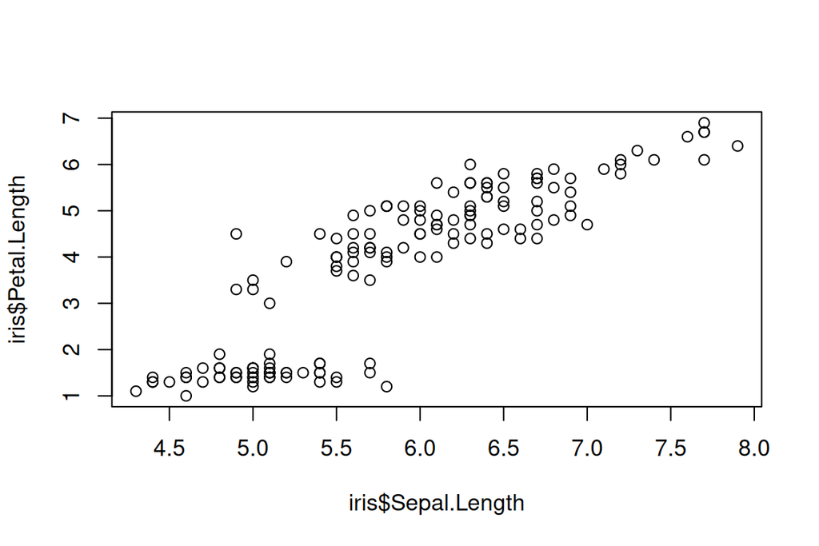

## Covariance

```r
cov(nerdy$TIPI1, nerdy$TIPI6)
```

```
[1] -1.951702
```

- What does this tell us about the relation between these two variables?

## Covariance

- We can also get all pairwise covariance of multiple variables by simply supplying the `cov()` function:

```r
cov(nerdy)
```

```
Error in cov(nerdy): is.numeric(x) || is.logical(x) is not TRUE
```

```r
head(nerdy)
```

```
# A tibble: 6 × 14
  country nerdy_scale continent TIPI1 TIPI2 TIPI3 TIPI4 TIPI5 TIPI6 TIPI7 TIPI8
  <chr>         <dbl> <chr>     <dbl> <dbl> <dbl> <dbl> <dbl> <dbl> <dbl> <dbl>
1 MA             3.31 Africa        4     4     1     5     5     6     5     1
2 ZA             4.04 Africa        3     6     4     4     3     7     6     5
3 SD             3.65 Africa        6     6     3     7     5     4     2     5
4 NG             2.42 Africa        2     7     2     5     5     1     3     5
5 ZA             3.58 Africa        4     7     6     5     4     5     3     3
6 ZA             4.5  Africa        2     2     3     5     7     5     7     7
# ℹ 3 more variables: TIPI9 <dbl>, TIPI10 <dbl>, nerdy_selfreport <dbl>
```

```r
nerdy_items <-  select(nerdy, TIPI1:TIPI3)
cov(nerdy_items)
```

```
          TIPI1      TIPI2      TIPI3
TIPI1 3.7951702 0.28353353 0.22722723
TIPI2 0.2835335 3.42132132 0.03123123
TIPI3 0.2272272 0.03123123 2.86246246
```

- The output of this is called a [variance-covariance matrix](https://www.cuemath.com/algebra/covariance-matrix/) and it describes (as the name suggests) the variances and covariances of the variables in your dataset.
- The diagonal elements of the variance-covariance matrix are the variances of the variables. Why? Because the way that a variable relates to itself is just its spread.
- The off-diagonal elements are the covariances between each pair of variables. Notice that this matrix is symmetric.

## Correlation

- Correlation is a standardized covariance, and since it can only fall between -1 and 1.
- It makes it easier to interpret the value as a measure of the strength of the relation.

```r
cor(nerdy_items)
```

```
           TIPI1      TIPI2      TIPI3
TIPI1 1.00000000 0.07868499 0.06894057
TIPI2 0.07868499 1.00000000 0.00997981
TIPI3 0.06894057 0.00997981 1.00000000
```

- Which relations appear to be strong? Which ones appear to be weak?

## Significance Testing for a Correlation

- We calculated our correlations, but we aren’t able to tell whether these values are represent significant relations – significant meaning that the correlation coefficient is different from 0.
- First, let’s plot our data – we want to make sure that using the correlation to quantify the relationship between the variables is suitable, because correlation and covariance can only capture linear relations.
- We also don’t want to necessarily use correlation if there are strong outliers in our data, as those outliers can change the value of our correlation coefficient.

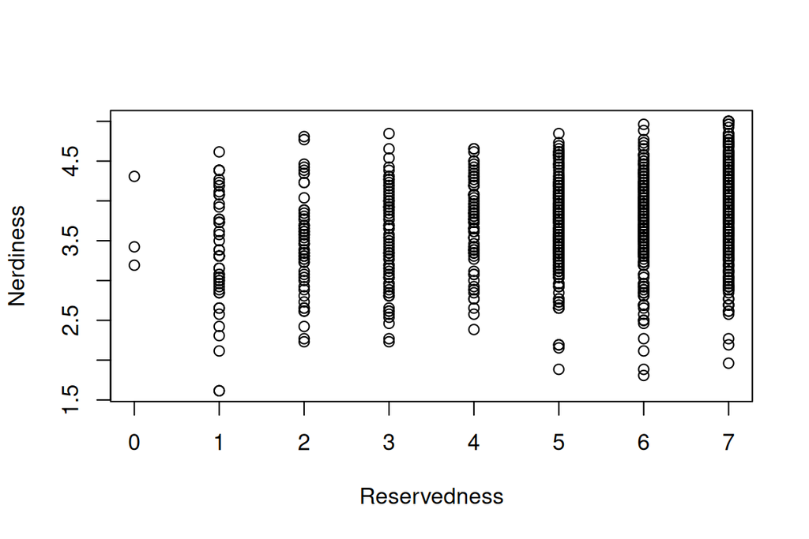

```r
plot(nerdy$TIPI6, nerdy$nerdy_scale, xlab = "Reservedness", ylab = "Nerdiness")
```

## Significance Testing for a Correlation

- Our null and alternative hypotheses are:
  - $H_0$: $\rho_{xy}$ = 0
  - $H_1$: $\rho_{xy} \neq$ 0
- This is a **two-sided test** – either there is a relation or there isn’t a relation.
- We’re not specifying which direction we expect that relation to be in.

## Significance Testing for a Correlation

```r
cor.test(nerdy$TIPI6, nerdy$nerdy_scale, method = "pearson")
```

```
    Pearson's product-moment correlation

data:  nerdy$TIPI6 and nerdy$nerdy_scale
t = 7.6354, df = 998, p-value = 5.256e-14
alternative hypothesis: true correlation is not equal to 0
95 percent confidence interval:
 0.1754925 0.2926604
sample estimates:
      cor
0.2349297
```

## Write-up the results

**Exercise**

Choose another pair of variables that you want to test whether or not are correlated. Using the `cor.test()` function describe whether the association is statistically significant, its direction (positive or negative), and all the relevant test statistics (*r*, 95% CI, *t*, df, and *p*).

- `TIPI1`: extraverted/enthusiastic
- `TIPI2`: critical, quarrelsome
- `TIPI3`: dependable, self-disciplined
- `TIPI4`: Anxious, easily upset
- `TIPI5`: open to new experiences, complex
- `TIPI6`: reserved, quiet
- `TIPI7`: sympathetic, warm
- `TIPI8`: disorganized, careless
- `TIPI9`: calm, emotionally stable
- `TIPI10`: convetional, uncreative

## Simple linear regression

- In our discussion of covariance and correlation, we’ve only talked about whether the two variables are associated with each other.
- None of this looks at whether one variable has an effect on the other variable.
- Now we’re looking at the relation between a **dependent variable** and at least one **predictor variable**.
- We’ve moved to the context of the predictor variable having an effect on the dependent variable.

## Simple linear regression

What if we were interested in whether how extraverted someone is (TIPI1) predicts how nerdy they are?

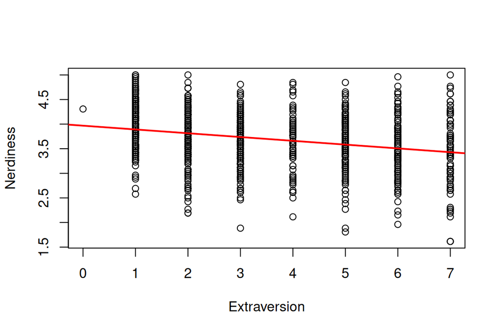

## Simple linear regression

$$\hat{Y_i} = b_0 + b_1 X_{1i}$$

- $\hat{Y_i}$ is the predicted value of our outcome for a given value of $X$.
- $b_0$ represents the intercept, which is the value of the outcome when the predictor is 0.
- $b_1$ represents the slope – the expected amount of change in our outcome when our predictor increases by 1 unit.
- The best regression line is the one that minimizes the sum of squared residuals ($\sum^N_{i=1}(y_i-\hat{y}_i)^2$)

## Simple linear regression

- To run a linear regression in `R`, we can use the `lm()` function we’re already familiar with

```r
simple_regression <- lm(nerdy_scale ~ TIPI1, data = nerdy)
```

## Simple linear regression

- Let’s take a look at the output using the `summary()` function:

```r
summary(simple_regression)
```

```
Call:
lm(formula = nerdy_scale ~ TIPI1, data = nerdy)

Residuals:
    Min      1Q  Median      3Q     Max
-1.8521 -0.3515 -0.0048  0.3795  1.5721

Coefficients:
             Estimate Std. Error t value Pr(>|t|)
(Intercept)  3.968414   0.035869 110.636   <2e-16 ***
TIPI1       -0.077219   0.009005  -8.575   <2e-16 ***
---
Signif. codes:  0 '***' 0.001 '**' 0.01 '*' 0.05 '.' 0.1 ' ' 1

Residual standard error: 0.5545 on 998 degrees of freedom
Multiple R-squared:  0.06863,   Adjusted R-squared:  0.06769
F-statistic: 73.54 on 1 and 998 DF,  p-value: < 2.2e-16
```

## Hypothesis Testing for the Slope and R-Squared

```
              Estimate  Std. Error    t value     Pr(>|t|)
(Intercept)  3.9684140 0.035869035 110.636208 0.000000e+00
TIPI1       -0.0772193 0.009004763  -8.575384 3.722454e-17
```

- In addition to the estimates of the intercept and slope, we also have a standard error, test statistic, and p-value.
- These are for testing the null hypothesis that the parameter is equal to 0 versus the alternative that it’s not equal to 0.
  - $H_0$: $b_1$ = 0
  - $H_1$: $b_1 \neq$ 0
- The t-statistic in this test is distributed as a t-distribution with N - 2 df. What is the df for our example? 1000 - 2 = 998

## Hypothesis Testing for the Slope and R-Squared

- Typically, we’re more interested in the test for the slope because that tells us whether the predictor is useful in predicting the outcome.
- Otherwise, the slope is no different from 0 and there is no linear relation, no useful relation between $X$ and $Y$ that we can use to predict $Y$.

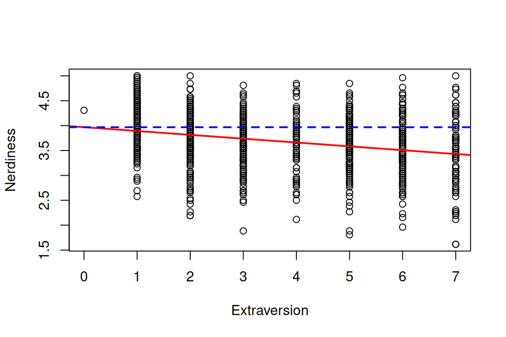

## 95% CI for the Slope

- We can also ask `R` a confidence interval arond our estimate of the slope:

```r
confint(simple_regression)
```

```
                  2.5 %      97.5 %
(Intercept)  3.89802660  4.03880136
TIPI1       -0.09488974 -0.05954885
```

## R-Squared

- One other piece of useful information that you get from the `summary()` output is R-squared, also called the **coefficient of determination**.
- R-squared ($R^2$) is equivalent to eta-squared ($\eta^2$) that we learned about in ANOVA.
- $R^2$ is the proportion of total variability in our outcome that is explained by our predictor(s)

```r
summary(simple_regression)$r.squared
```

```
[1] 0.06862777
```

## Write-up the results

> We ran a simple linear regression to determine whether participant’s extraversion score predicts their nerdiness score on the NPAS. Extraversion did significantly predict the NPAS score (*b* = -0.08, *p* < .001). Extraversion explained 6.8% of the total variability in NPAS score.

## What about Bayes?

```r
library(BayesFactor)
regressionBF(nerdy_scale ~ TIPI1, data = nerdy)
```

```
Bayes factor analysis
--------------
[1] TIPI1 : 1.192446e+14 ±0%

Against denominator:
  Intercept only
---
Bayes factor type: BFlinearModel, JZS
```

**Exercise**

Choose another variable that you think might predict nerdiness, and calculate the regression model both using the formula, and with the `lm()` function Interpret the output (the intercept, slope, and $R^2$). Was the slope significant? What does that mean?

- `TIPI1`: extraverted/enthusiastic
- `TIPI2`: critical, quarrelsome
- `TIPI3`: dependable, self-disciplined
- `TIPI4`: Anxious, easily upset
- `TIPI5`: open to new experiences, complex
- `TIPI6`: reserved, quiet
- `TIPI7`: sympathetic, warm
- `TIPI8`: disorganized, careless
- `TIPI9`: calm, emotionally stable
- `TIPI10`: convetional, uncreative

PSC 103B - Statistical Analysis of Psychological Data